# Worked Example: Air Quality

The same plotting tasks in R and Python

Authors

Johan Larsson

Behnaz Pirzamanbein

Jonas Wallin

We explore air-quality measurements from New York between May and September 1973, first as pairs of variables and then over time. We use **ggplot2** in R and **seaborn/matplotlib** in Python. Choose a language in any tab to switch all the tabs, and run the examples in order so that earlier objects are available.

Keep the `data` folder beside this file. See First Steps with ggplot2 for the building blocks of a plot in both languages.

## Getting started

Install packages once, then load or import them in each new session. Python uses pandas for tables, statsmodels for linear regression, and scikit-misc for LOESS and its confidence intervals.

**R**

If needed, run this once:

```r
install.packages(c("tidyverse", "lubridate", "patchwork"))
```

```r
library(tidyverse)
library(lubridate)
library(patchwork)
```

**Python**

If needed, run this once in a terminal:

```bash
python -m pip install numpy pandas matplotlib seaborn statsmodels scikit-misc
```

```python
from pathlib import Path
import numpy as np
import pandas as pd
import matplotlib.pyplot as plt
import matplotlib.dates as mdates
import seaborn as sns
import statsmodels.api as sm
from skmisc.loess import loess

DATA_DIR = Path("data")
sns.set_theme(style="whitegrid", context="notebook")
```

**NoteRendering the Quarto source**

You can read the HTML page and copy examples without rendering it yourself. To render `airquality.qmd`, install Quarto, the R packages above, `knitr`, `rmarkdown`, and `reticulate`, and the Python packages listed above. Both languages run when the document is rendered.

Quarto uses [knitr and reticulate to run R and Python together](https://quarto.org/docs/computations/execution-options.html#engine-binding). Select a Python environment containing these packages; see [Python version configuration](https://rstudio.github.io/reticulate/articles/versions.html).

Open this file in RStudio and click **Render**, or run this command from the folder containing the file:

```bash
quarto render airquality.qmd
```

## Air quality in New York

When studying two numeric variables, a scatter plot is a useful starting point. The `airquality` dataset contains daily measurements from New York between May and September 1973.

The variables are:

- `Ozone`: mean ozone in parts per billion (ppb), measured from 1300 to 1500 hours at Roosevelt Island.
- `Solar.R`: solar radiation in Langleys, in the frequency band 4000–7700 Angstroms, measured from 0800 to 1200 hours at Central Park.
- `Wind`: average wind speed in miles per hour (mph), measured at 0700 and 1000 hours at LaGuardia Airport.
- `Temp`: maximum daily temperature in degrees Fahrenheit at LaGuardia Airport.
- `Month`, `Day`: the month and day of the measurement.

The dataset is built into R. Python reads a CSV copy of the same data, including its missing measurements. Here are the first few rows.

**R**

```r
head(airquality)
```

```
  Ozone Solar.R Wind Temp Month Day
1    41     190  7.4   67     5   1
2    36     118  8.0   72     5   2
3    12     149 12.6   74     5   3
4    18     313 11.5   62     5   4
5    NA      NA 14.3   56     5   5
6    28      NA 14.9   66     5   6
```

**Python**

```python
airquality = pd.read_csv(DATA_DIR / "airquality.csv")
airquality.head()
```

```
   Ozone  Solar.R  Wind  Temp  Month  Day
0   41.0    190.0   7.4    67      5    1
1   36.0    118.0   8.0    72      5    2
2   12.0    149.0  12.6    74      5    3
3   18.0    313.0  11.5    62      5    4
4    NaN      NaN  14.3    56      5    5
```

Let’s begin with wind and ozone. If we are interested in how ozone varies with wind speed, a natural mapping places wind speed on the x axis and ozone on the y axis.

**R**

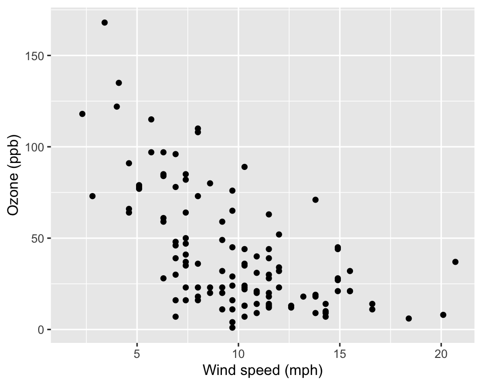

```r
ggplot(airquality, aes(x = Wind, y = Ozone)) +
  geom_point() +
  labs(x = "Wind speed (mph)", y = "Ozone (ppb)")
```

**Python**

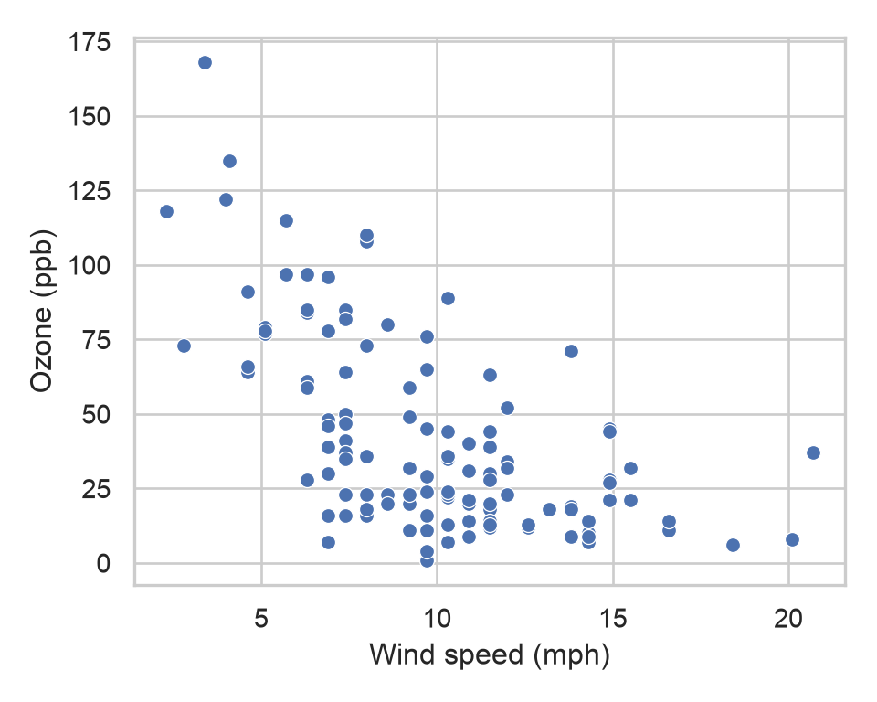

```python
fig, ax = plt.subplots(figsize=(5, 4))
sns.scatterplot(data=airquality, x="Wind", y="Ozone", ax=ax)
ax.set(xlabel="Wind speed (mph)", ylabel="Ozone (ppb)")
fig.tight_layout()
plt.show()
```

Ozone tends to decrease as wind speed increases, but the downward curvature suggests that a straight line may be too restrictive. An inverse relationship, such as

$$\text{ozone} = \frac{c}{\text{wind speed}}$$

for some constant $c$, is one possible model. The scatter plot alone does not establish this particular form.

## Linear regression and LOESS

Scatter plots show the variation between individual days. Adding a fitted line helps us see the average trend. We will compare two choices:

- Linear regression fits a straight line by least squares.
- LOESS fits local regressions, allowing the curve to bend.

### Adding the fits

Let’s begin with the wind–ozone scatter plot. Slightly transparent points make overlapping observations easier to see.

**R**

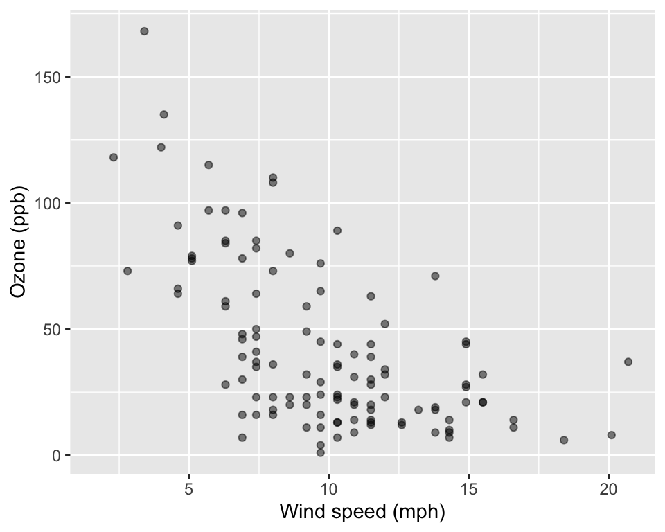

```r
ozone_wind <-
  ggplot(airquality, aes(x = Wind, y = Ozone)) +
  geom_point(alpha = 0.5) +
  labs(x = "Wind speed (mph)", y = "Ozone (ppb)")

ozone_wind
```

**Python**

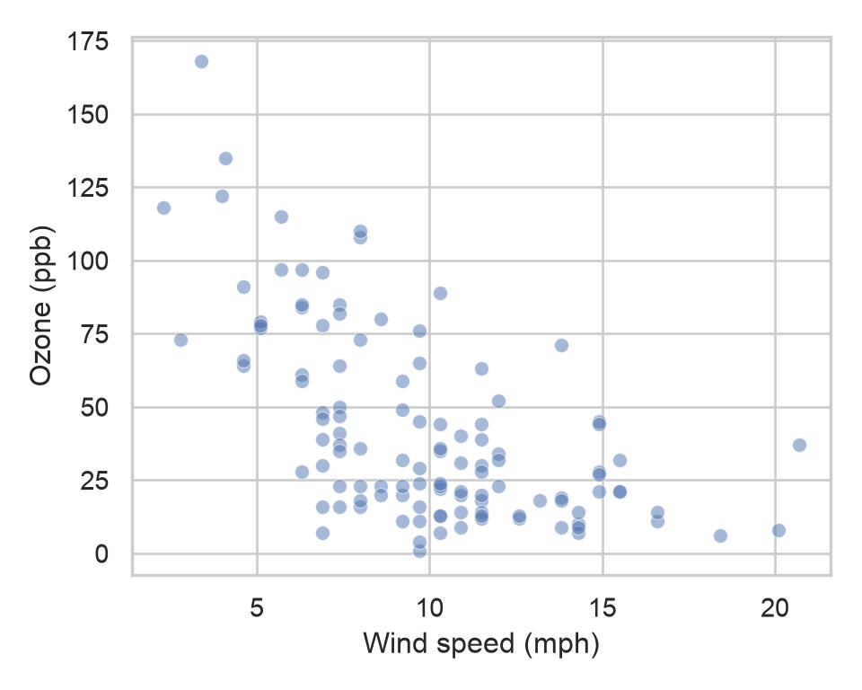

```python
fig, ax = plt.subplots(figsize=(5, 4))
sns.scatterplot(data=airquality, x="Wind", y="Ozone", alpha=0.5, ax=ax)
ax.set(xlabel="Wind speed (mph)", ylabel="Ozone (ppb)")
fig.tight_layout()
plt.show()
```

We will use a dashed blue line for linear regression and a solid orange curve for LOESS. In R, a fitted layer can be saved and reused. In Python, we define a helper that fits both models and draws their predictions on the supplied axes. It also returns the fitted models for the confidence-band example later.

Each fit uses the observations with both plotted variables available. Both LOESS implementations use local quadratic fits with a span of `0.75`.

**R**

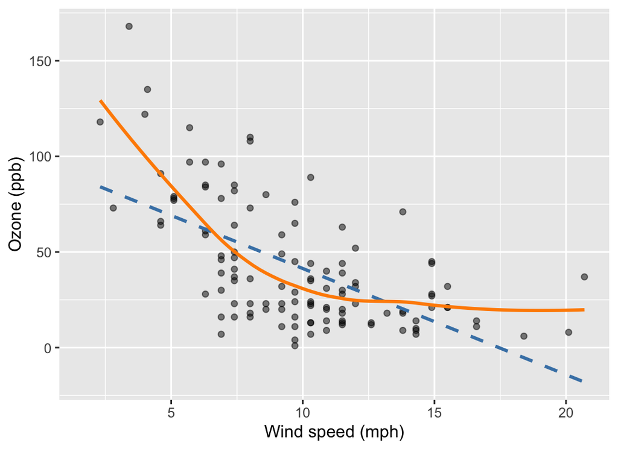

```r
linear_fit <- geom_smooth(
  method = "lm", formula = y ~ x, se = FALSE,
  colour = "steelblue", linetype = "dashed"
)

loess_fit <- geom_smooth(
  method = "loess", formula = y ~ x, span = 0.75, se = FALSE,
  colour = "darkorange"
)

ozone_wind + linear_fit + loess_fit
```

Here, `x` and `y` in `y ~ x` refer to the variables mapped to the axes. `se = FALSE` hides the confidence bands while we compare the fitted trends.

**Python**

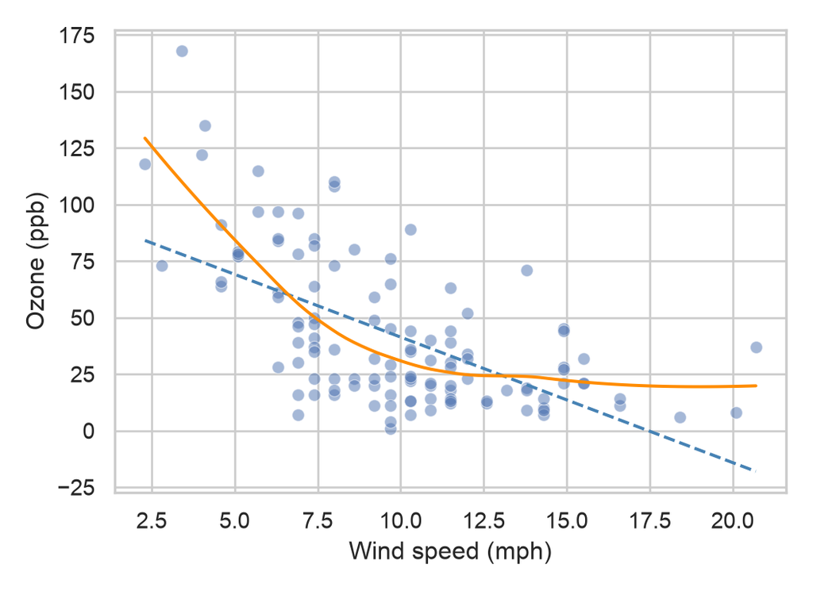

```python
def add_trends(x, y, data, ax, span=0.75):
    pair = data[[x, y]].dropna()
    x_grid = np.linspace(pair[x].min(), pair[x].max(), 80)

    linear_fit = sm.OLS(pair[y], sm.add_constant(pair[x])).fit()
    loess_fit = loess(
        pair[x].to_numpy(), pair[y].to_numpy(), span=span, degree=2
    )
    loess_fit.fit()

    ax.plot(
        x_grid, linear_fit.predict(sm.add_constant(x_grid)),
        color="steelblue", linestyle="--"
    )
    ax.plot(x_grid, loess_fit.predict(x_grid).values, color="darkorange")
    return x_grid, linear_fit, loess_fit


fig, ax = plt.subplots(figsize=(5.5, 4))
sns.scatterplot(data=airquality, x="Wind", y="Ozone", alpha=0.5, ax=ax)
fitted_trends = add_trends("Wind", "Ozone", data=airquality, ax=ax)
ax.set(xlabel="Wind speed (mph)", ylabel="Ozone (ppb)")
fig.tight_layout()
plt.show()
```

`sm.add_constant()` adds the intercept to the linear model. The LOESS prediction gives the fitted mean at each value in `x_grid`.

A LOESS span of `0.75` uses roughly three quarters of the observations for each local fit. Smaller values give more flexible curves, while larger values give smoother curves. See the documentation for [ggplot2 smoothing](https://ggplot2.tidyverse.org/reference/geom_smooth.html) and [scikit-misc LOESS](https://has2k1.github.io/scikit-misc/stable/generated/skmisc.loess.loess.html).

## Comparing all six relationships

Take some time to plot the associations between `Ozone`, `Solar.R`, `Wind`, and `Temp` and try to identify any patterns you observe.

There are six distinct pairs among these four variables. We can put the pairs in a table and define each axis label once. This section uses functions and iteration to avoid repeating the plotting code.

**R**

```r
variable_labels <- c(
  Ozone = "Ozone (ppb)",
  Solar.R = "Solar radiation\n(Langleys)",
  Wind = "Wind speed (mph)",
  Temp = "Temperature (F)"
)

plot_pairs <- tribble(
  ~x,        ~y,
  "Wind",    "Ozone",
  "Temp",    "Ozone",
  "Solar.R", "Ozone",
  "Wind",    "Temp",
  "Solar.R", "Temp",
  "Solar.R", "Wind"
)

scatter_plot <- function(x, y, data, labels) {
  ggplot(data, aes(x = .data[[x]], y = .data[[y]])) +
    geom_point(alpha = 0.5) +
    labs(x = labels[[x]], y = labels[[y]])
}

plot_pairs <- plot_pairs %>%
  mutate(scatter = map2(
    x, y, scatter_plot, data = airquality, labels = variable_labels
  ))

head(plot_pairs)
```

```
# A tibble: 6 × 3
  x       y     scatter
  <chr>   <chr> <list>
1 Wind    Ozone <ggplt2::>
2 Temp    Ozone <ggplt2::>
3 Solar.R Ozone <ggplt2::>
4 Wind    Temp  <ggplt2::>
5 Solar.R Temp  <ggplt2::>
6 Solar.R Wind  <ggplt2::>
```

The entries in `x` and `y` are column names stored as strings. `.data[[x]]` tells ggplot to look up the column whose name is stored in `x`; `aes()` records this lookup and evaluates it when the plot is built. `map2()` calls `scatter_plot()` for each pair, passing the same data and labels each time. The resulting `scatter` column is a list of plots.

**Python**

```python
variable_labels = {
    "Ozone": "Ozone (ppb)",
    "Solar.R": "Solar radiation\n(Langleys)",
    "Wind": "Wind speed (mph)",
    "Temp": "Temperature (F)",
}

plot_pairs = pd.DataFrame({
    "x": ["Wind", "Temp", "Solar.R", "Wind", "Solar.R", "Solar.R"],
    "y": ["Ozone", "Ozone", "Ozone", "Temp", "Temp", "Wind"],
})


def scatter_plot(x, y, data, labels, ax):
    sns.scatterplot(data=data, x=x, y=y, alpha=0.5, ax=ax)
    ax.set(xlabel=labels[x], ylabel=labels[y])


plot_pairs.head()
```

```
         x      y
0     Wind  Ozone
1     Temp  Ozone
2  Solar.R  Ozone
3     Wind   Temp
4  Solar.R   Temp
```

Seaborn accepts column names as strings directly. Our helper draws each pair on the supplied axes, using the same data and label dictionary each time.

We can now arrange all six scatter plots together. R uses **patchwork** to arrange its list of plots. Python creates six axes and loops over the rows of the pair table.

**R**

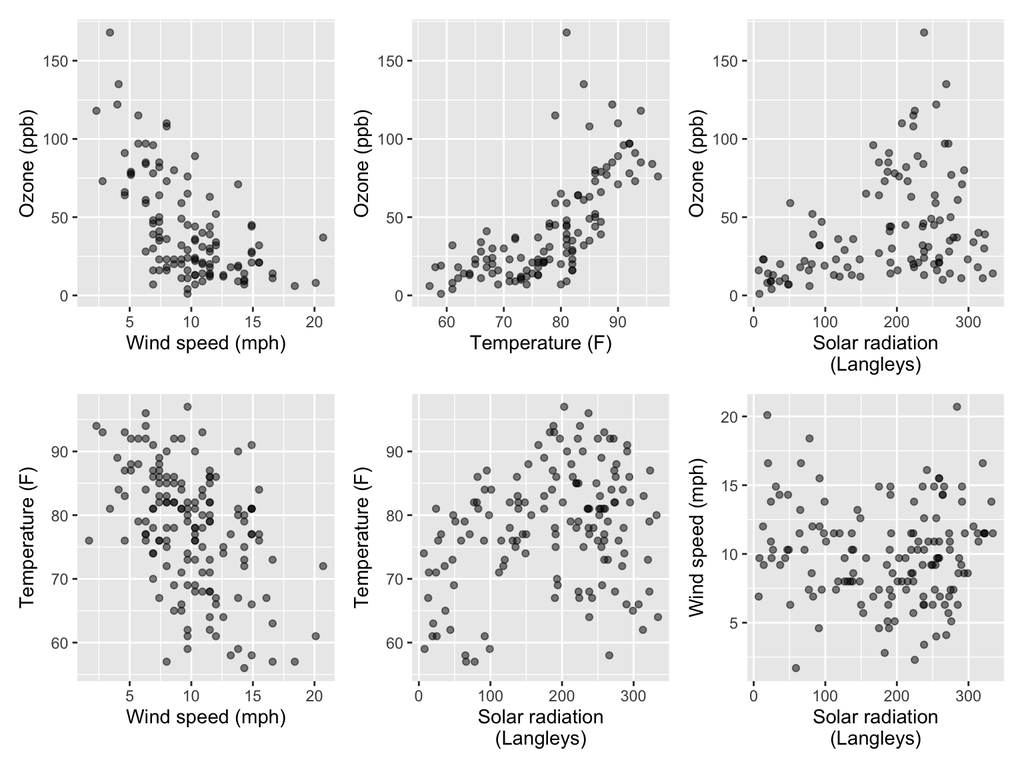

```r
wrap_plots(plot_pairs$scatter, ncol = 3)
```

**Python**

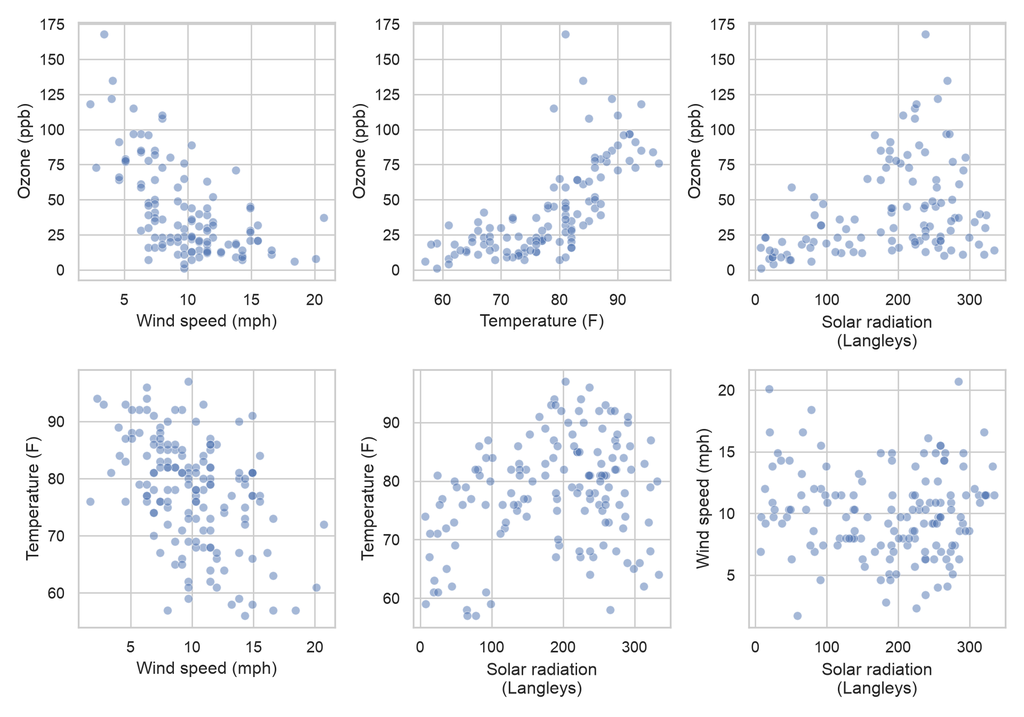

```python
fig, axes = plt.subplots(2, 3, figsize=(10, 7))
for ax, (x, y) in zip(axes.flat, plot_pairs.itertuples(index=False, name=None)):
    scatter_plot(x, y, data=airquality, labels=variable_labels, ax=ax)
fig.tight_layout()
plt.show()
```

Which relationships look roughly linear, and which suggest curvature?

### Adding fits to all six relationships

We can extend `scatter_plot()` with the fitted trends and reuse the same pair table to compare all six relationships.

**R**

```r
trend_plot <- function(x, y, data, labels) {
  scatter_plot(x, y, data, labels) +
    linear_fit +
    loess_fit
}

plot_pairs <- plot_pairs %>%
  mutate(plot = map2(
    x, y, trend_plot, data = airquality, labels = variable_labels
  ))
```

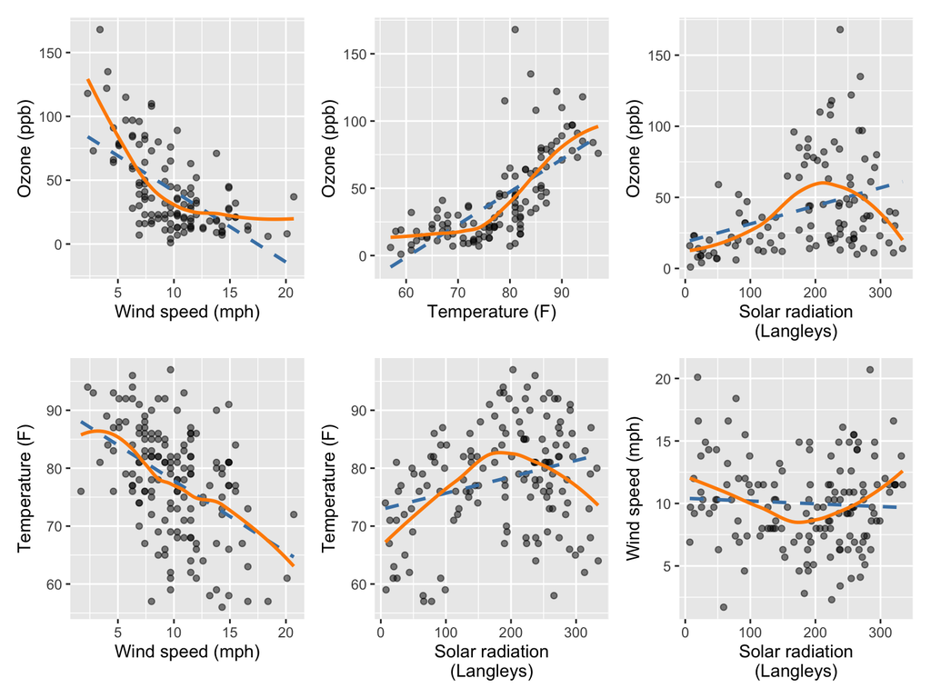

```r
wrap_plots(plot_pairs$plot, ncol = 3)
```

**Python**

```python
def trend_plot(x, y, data, labels, ax, span=0.75):
    scatter_plot(x, y, data=data, labels=labels, ax=ax)
    return add_trends(x, y, data=data, ax=ax, span=span)


fig, axes = plt.subplots(2, 3, figsize=(10, 7))
for ax, (x, y) in zip(axes.flat, plot_pairs.itertuples(index=False, name=None)):
    trend_plot(x, y, data=airquality, labels=variable_labels, ax=ax)
```

[output not shown]

[output cut: 53 more lines]

[output not shown]

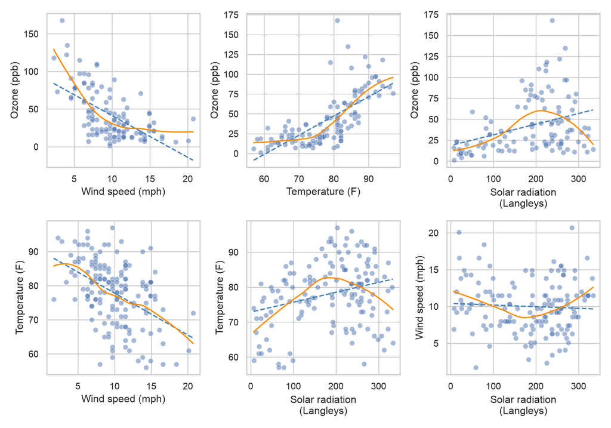

```python
fig.tight_layout()
plt.show()
```

Where does a straight line capture the main trend, and where does LOESS reveal curvature? Which relationships still show considerable scatter? Try changing the LOESS span to `0.5` or `1` and see which features remain visible. In R, update `loess_fit` and rebuild the plots; in Python, pass `span=0.5` or `span=1` to `trend_plot()`.

### Adding confidence bands

Now draw all six relationships again with confidence bands. The shading shows 95% confidence intervals for the estimated mean trend at each x value; the LOESS intervals are approximate. Individual days can vary much more than the width of these bands.

**R**

Replace the fitted layers with versions using `se = TRUE`, then reuse `trend_plot()`. `level = 0.95` sets the confidence level.

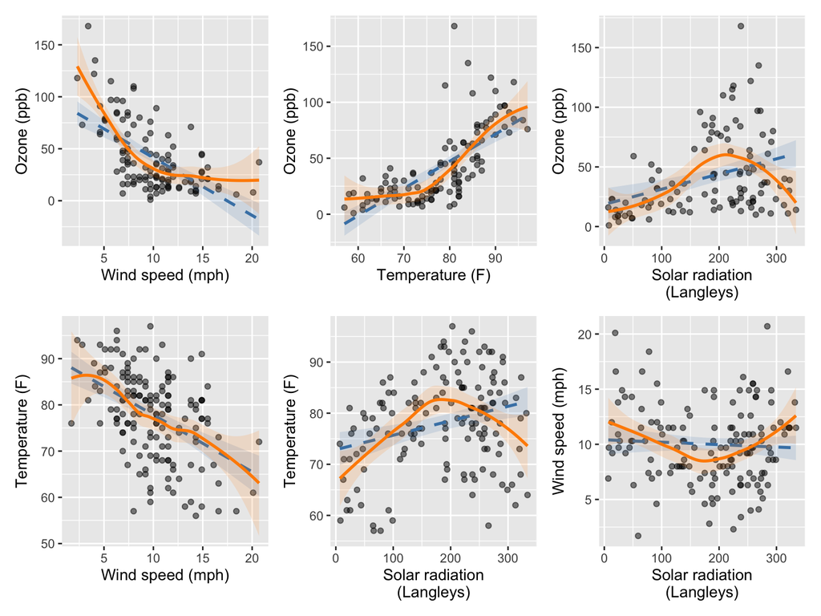

```r
linear_fit <- geom_smooth(
  method = "lm", formula = y ~ x, se = TRUE, level = 0.95,
  colour = "steelblue", fill = "steelblue", alpha = 0.15,
  linetype = "dashed"
)

loess_fit <- geom_smooth(
  method = "loess", formula = y ~ x, span = 0.75, se = TRUE, level = 0.95,
  colour = "darkorange", fill = "darkorange", alpha = 0.15
)

plot_pairs <- plot_pairs %>%
  mutate(plot_with_bands = map2(
    x, y, trend_plot, data = airquality, labels = variable_labels
  ))

wrap_plots(plot_pairs$plot_with_bands, ncol = 3)
```

**Python**

Use the fitted models returned by `trend_plot()` to obtain intervals, then draw the shading with `fill_between()`. The `mean_ci_lower` and `mean_ci_upper` columns contain intervals for the mean. An `alpha` of `0.05` gives 95% confidence intervals; the plotting `alpha=0.15` controls transparency.

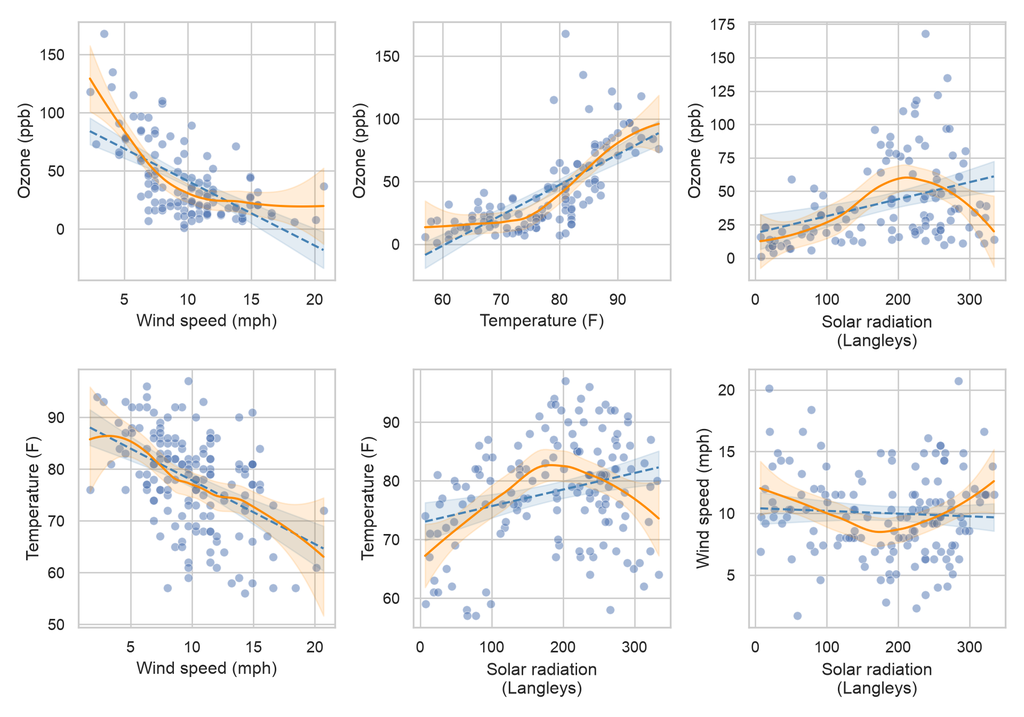

```python
fig, axes = plt.subplots(2, 3, figsize=(10, 7))
for ax, (x, y) in zip(axes.flat, plot_pairs.itertuples(index=False, name=None)):
    x_grid, linear_fit, loess_fit = trend_plot(
        x, y, data=airquality, labels=variable_labels, ax=ax
    )
    linear_bands = linear_fit.get_prediction(
        sm.add_constant(x_grid)
    ).summary_frame(alpha=0.05)
    loess_bands = loess_fit.predict(
        x_grid, stderror=True
    ).confidence(alpha=0.05)

    ax.fill_between(
        x_grid, linear_bands["mean_ci_lower"], linear_bands["mean_ci_upper"],
        color="steelblue", alpha=0.15
    )
    ax.fill_between(
        x_grid, loess_bands.lower, loess_bands.upper,
        color="darkorange", alpha=0.15
    )
fig.tight_layout()
plt.show()
```

See [statsmodels prediction intervals](https://www.statsmodels.org/stable/generated/statsmodels.regression.linear_model.OLSResults.get_prediction.html) and [scikit-misc pointwise confidence intervals](https://has2k1.github.io/scikit-misc/stable/generated/skmisc.loess.loess_prediction.html) for the Python methods used here.

## Longitudinal data

These data are longitudinal: measurements follow the same setting over time. Combine the day and month into a date to examine how ozone varies through the five months.

**R**

```r
airquality_formatted <-
  airquality %>%
  as_tibble() %>%
  mutate(Date = make_date(1973, Month, Day))

head(airquality_formatted)
```

```
# A tibble: 6 × 7
  Ozone Solar.R  Wind  Temp Month   Day Date
  <int>   <int> <dbl> <int> <int> <int> <date>
1    41     190   7.4    67     5     1 1973-05-01
2    36     118   8      72     5     2 1973-05-02
3    12     149  12.6    74     5     3 1973-05-03
4    18     313  11.5    62     5     4 1973-05-04
5    NA      NA  14.3    56     5     5 1973-05-05
6    28      NA  14.9    66     5     6 1973-05-06
```

**Python**

```python
airquality_formatted = airquality.copy()
airquality_formatted["Date"] = pd.to_datetime({
    "year": 1973,
    "month": airquality["Month"],
    "day": airquality["Day"],
})
airquality_formatted.head()
```

```
   Ozone  Solar.R  Wind  Temp  Month  Day       Date
0   41.0    190.0   7.4    67      5    1 1973-05-01
1   36.0    118.0   8.0    72      5    2 1973-05-02
2   12.0    149.0  12.6    74      5    3 1973-05-03
3   18.0    313.0  11.5    62      5    4 1973-05-04
4    NaN      NaN  14.3    56      5    5 1973-05-05
```

Here is our first attempt, using a line to show ozone over time.

**R**

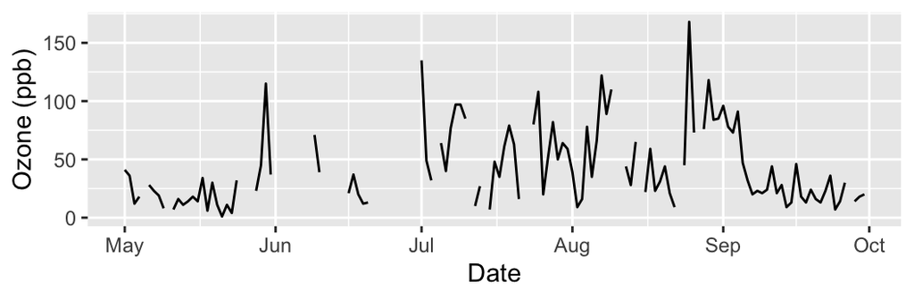

```r
p1 <-
  ggplot(airquality_formatted, aes(Date, Ozone)) +
  geom_line() +
  labs(y = "Ozone (ppb)")

p1
```

**Python**

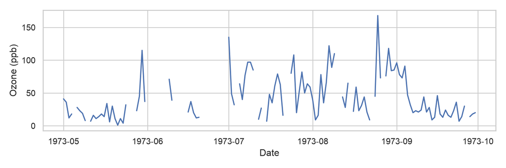

```python
fig, ax = plt.subplots(figsize=(9, 3))
ax.plot(airquality_formatted["Date"], airquality_formatted["Ozone"])
ax.set(xlabel="Date", ylabel="Ozone (ppb)")
fig.tight_layout()
plt.show()
```

Why are there holes in the plot? Missing ozone values break the line. An observed value surrounded by missing values has no line segment, so it is invisible without a point layer.

Dropping the missing values allows the remaining observations to connect, even when there are missing days between them.

**R**

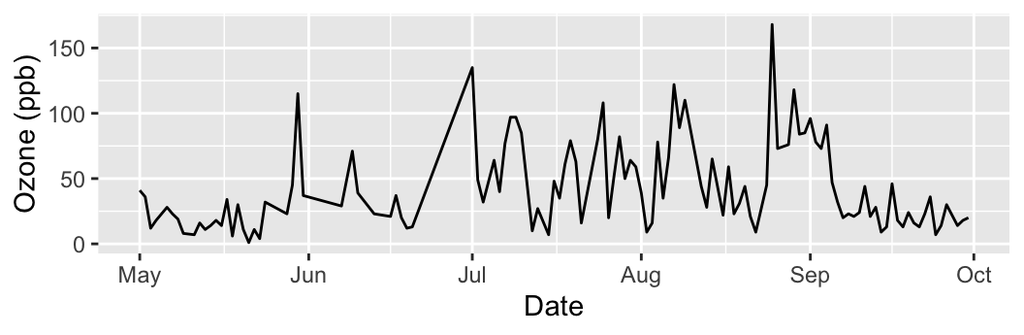

```r
airquality_nona <- drop_na(airquality_formatted, Ozone)

p2 <-
  ggplot(airquality_nona, aes(Date, Ozone)) +
  geom_line() +
  labs(y = "Ozone (ppb)")

p2
```

**Python**

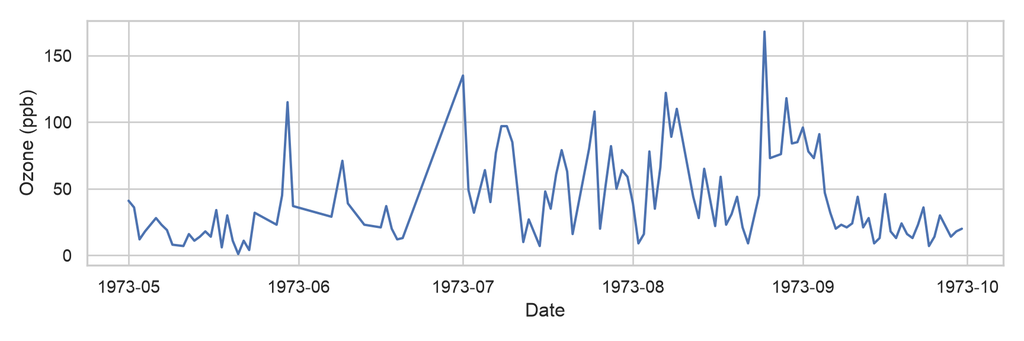

```python
airquality_nona = airquality_formatted.dropna(subset=["Ozone"]).copy()

fig, ax = plt.subplots(figsize=(9, 3))
ax.plot(airquality_nona["Date"], airquality_nona["Ozone"])
ax.set(xlabel="Date", ylabel="Ozone (ppb)")
fig.tight_layout()
plt.show()
```

Adding points shows which dates have observed measurements, although the lines still connect across missing days.

**R**

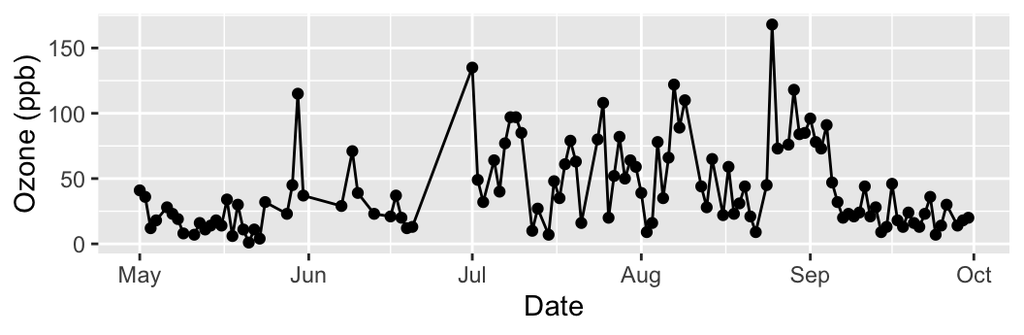

```r
p3 <- p2 + geom_point()
p3
```

**Python**

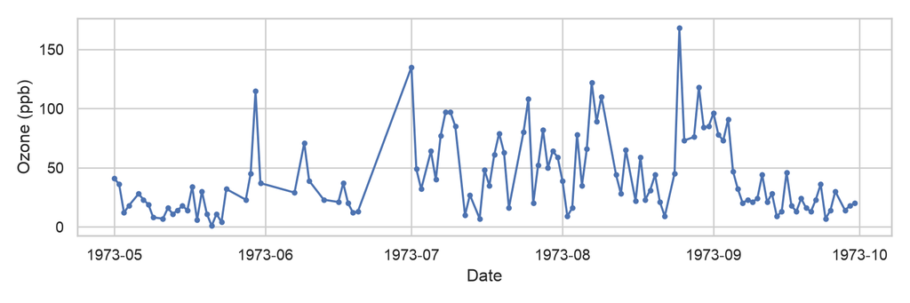

```python
fig, ax = plt.subplots(figsize=(9, 3))
ax.plot(
    airquality_nona["Date"], airquality_nona["Ozone"],
    marker="o", markersize=3
)
ax.set(xlabel="Date", ylabel="Ozone (ppb)")
fig.tight_layout()
plt.show()
```

### Keeping gaps for missing observations

To leave gaps where measurements are missing, keep the original rows and add points. The line breaks at missing measurements, while the points show all observed values. In R, `na.rm = TRUE` silently omits missing points; it does not change the data used by the line layer. Matplotlib also leaves gaps at missing values when drawing the line.

**R**

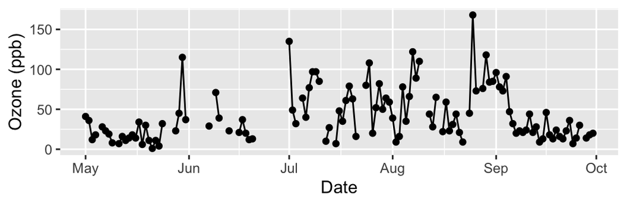

```r
p_gaps <- p1 + geom_point(na.rm = TRUE)
p_gaps
```

**Python**

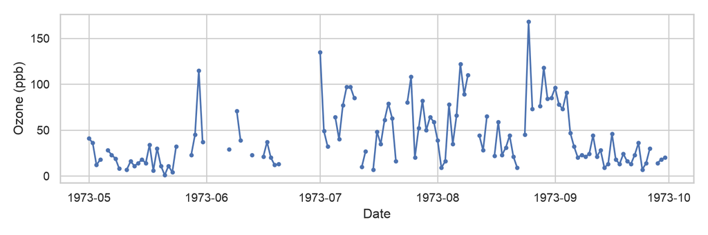

```python
fig, ax = plt.subplots(figsize=(9, 3))
ax.plot(
    airquality_formatted["Date"], airquality_formatted["Ozone"],
    marker="o", markersize=3
)
ax.set(xlabel="Date", ylabel="Ozone (ppb)")
fig.tight_layout()
plt.show()
```

Compare this with the previous plot: where did dropping missing values join observations across missing days?

### Air pollution across the week

We might wonder whether ozone differs between weekdays and weekends. Weekly grid lines can help us look for a repeating pattern in the time plot. They mark weekly intervals, rather than identifying both weekend days separately.

**R**

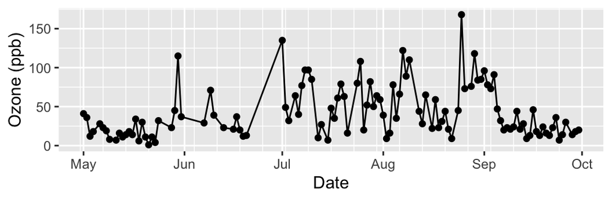

```r
p4 <- p3 + scale_x_date(minor_breaks = "weeks")
p4
```

**Python**

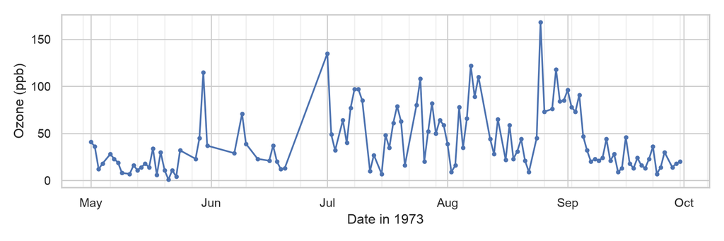

```python
fig, ax = plt.subplots(figsize=(9, 3))
ax.plot(
    airquality_nona["Date"], airquality_nona["Ozone"],
    marker="o", markersize=3
)
ax.xaxis.set_major_locator(mdates.MonthLocator())
ax.xaxis.set_major_formatter(mdates.DateFormatter("%b"))
ax.xaxis.set_minor_locator(mdates.WeekdayLocator(byweekday=mdates.SU))
ax.grid(which="minor", axis="x", alpha=0.3)
ax.set(xlabel="Date in 1973", ylabel="Ozone (ppb)")
fig.tight_layout()
plt.show()
```

It is hard to see a clear weekly pattern because ozone varies substantially from day to day. Let’s instead create a variable representing the day of the week.

The default R `wday()` numbering is **1 for Sunday through 7 for Saturday**. Pandas starts at **0 for Monday through 6 for Sunday**, so we convert its numbers to match the R example.

**R**

```r
airquality_1973 <-
  airquality_nona %>%
  mutate(Weekday = wday(Date))

head(airquality_1973)
```

```
# A tibble: 6 × 8
  Ozone Solar.R  Wind  Temp Month   Day Date       Weekday
  <int>   <int> <dbl> <int> <int> <int> <date>       <dbl>
1    41     190   7.4    67     5     1 1973-05-01       3
2    36     118   8      72     5     2 1973-05-02       4
3    12     149  12.6    74     5     3 1973-05-03       5
4    18     313  11.5    62     5     4 1973-05-04       6
5    28      NA  14.9    66     5     6 1973-05-06       1
6    23     299   8.6    65     5     7 1973-05-07       2
```

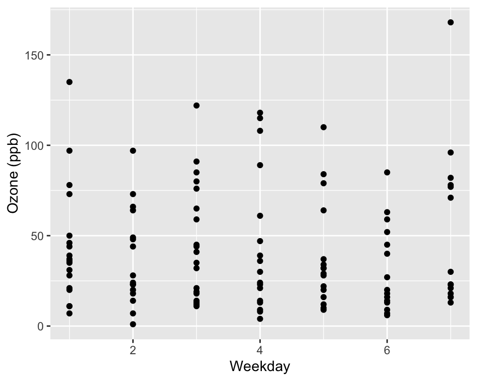

```r
ggplot(airquality_1973, aes(Weekday, Ozone)) +
  geom_point() +
  labs(y = "Ozone (ppb)")
```

**Python**

```python
airquality_1973 = airquality_nona.copy()
airquality_1973["Weekday"] = (airquality_1973["Date"].dt.dayofweek + 1) % 7 + 1
airquality_1973.head()
```

```
   Ozone  Solar.R  Wind  Temp  Month  Day       Date  Weekday
0   41.0    190.0   7.4    67      5    1 1973-05-01        3
1   36.0    118.0   8.0    72      5    2 1973-05-02        4
2   12.0    149.0  12.6    74      5    3 1973-05-03        5
3   18.0    313.0  11.5    62      5    4 1973-05-04        6
5   28.0      NaN  14.9    66      5    6 1973-05-06        1
```

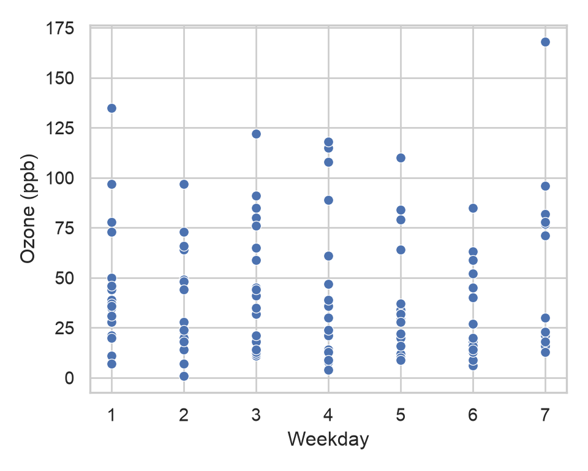

```python
fig, ax = plt.subplots(figsize=(5, 4))
sns.scatterplot(data=airquality_1973, x="Weekday", y="Ozone", ax=ax)
ax.set(ylabel="Ozone (ppb)", xticks=range(1, 8))
fig.tight_layout()
plt.show()
```

Box plots make the distributions easier to compare. In R, converting the weekday numbers to a factor creates separate groups for the boxes. `as.ordered()` uses the existing numeric order; it does not discover the calendar order. A regular factor would also create separate groups. Python uses an ordered categorical column to make the group order explicit.

**R**

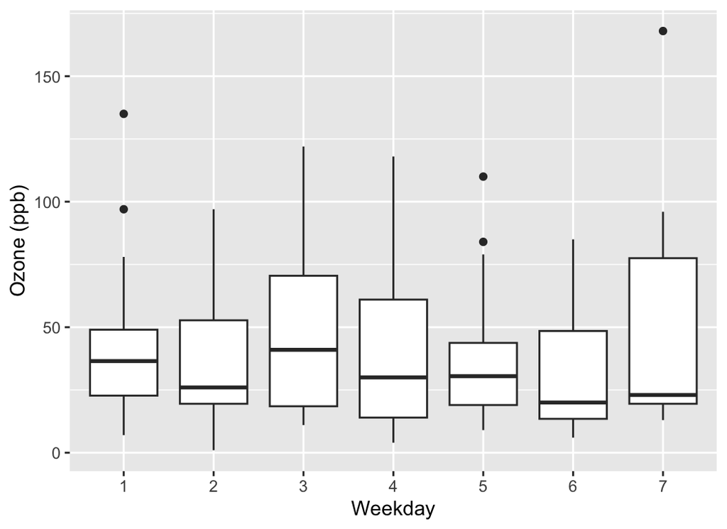

```r
ggplot(airquality_1973, aes(as.ordered(Weekday), Ozone)) +
  geom_boxplot() +
  labs(x = "Weekday", y = "Ozone (ppb)")
```

**Python**

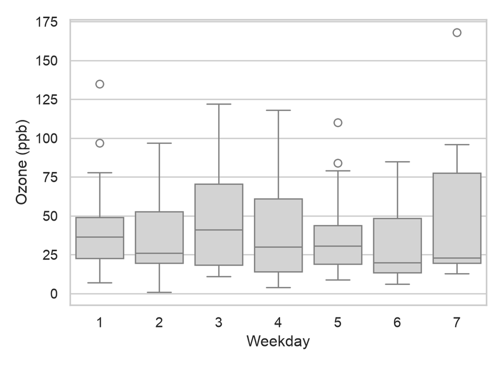

```python
airquality_1973["Weekday"] = pd.Categorical(
    airquality_1973["Weekday"], categories=range(1, 8), ordered=True
)

fig, ax = plt.subplots(figsize=(5.5, 4))
sns.boxplot(data=airquality_1973, x="Weekday", y="Ozone", color="lightgray", ax=ax)
ax.set(xlabel="Weekday", ylabel="Ozone (ppb)")
fig.tight_layout()
plt.show()
```

There is no clear pattern across the days of the week. Do the box plots suggest any consistent difference between weekends and other days?

Additionally, take some time to visualize the relationships between time and the other variables in the dataset.

### Using day names on the axis

Day names make it easier to identify weekdays and weekends. We keep Sunday first to match the numbered plots. R’s `wday(label = TRUE)` creates an ordered factor directly; Python uses a categorical column with an explicit order. The `"C"` locale gives English day names in both examples.

**R**

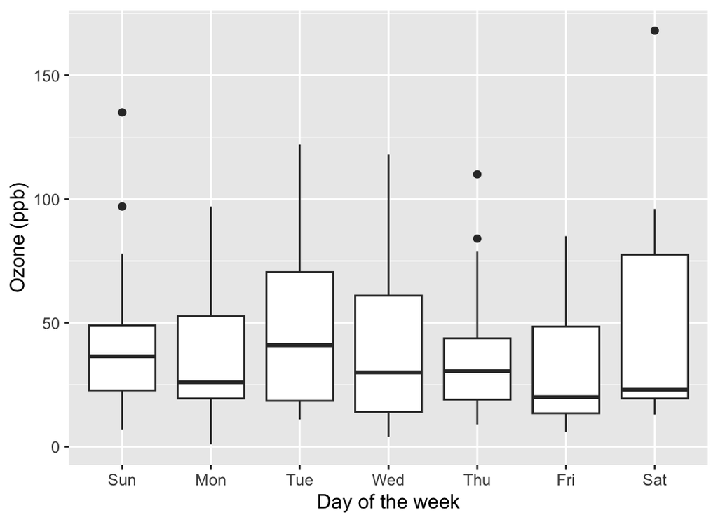

```r
airquality_1973_named <-
  airquality_nona %>%
  mutate(Weekday = wday(Date, label = TRUE, week_start = 7, locale = "C"))

ggplot(airquality_1973_named, aes(Weekday, Ozone)) +
  geom_boxplot() +
  labs(x = "Day of the week", y = "Ozone (ppb)")
```

**Python**

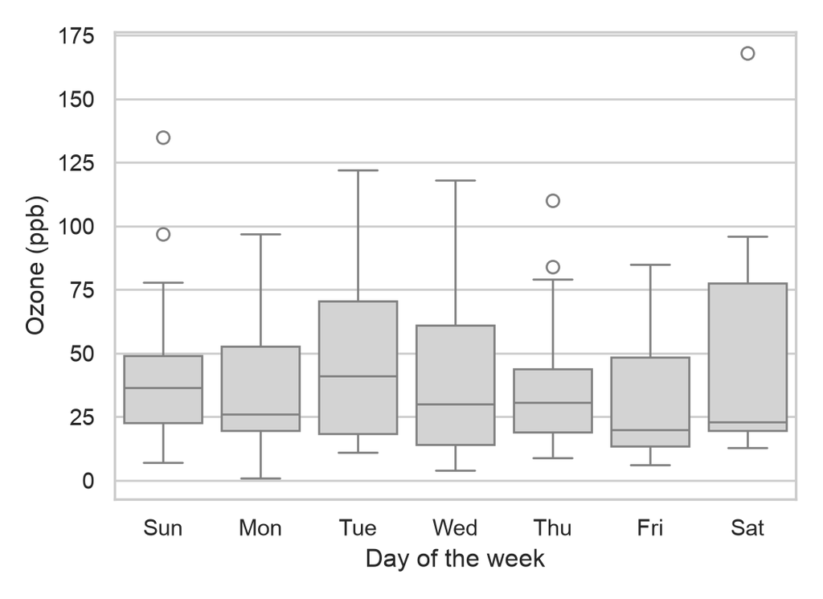

```python
weekday_order = ["Sun", "Mon", "Tue", "Wed", "Thu", "Fri", "Sat"]
airquality_1973_named = airquality_nona.copy()
airquality_1973_named["Weekday"] = pd.Categorical(
    airquality_1973_named["Date"].dt.day_name(locale="C").str[:3],
    categories=weekday_order, ordered=True
)

fig, ax = plt.subplots(figsize=(5.5, 4))
sns.boxplot(
    data=airquality_1973_named, x="Weekday", y="Ozone", color="lightgray", ax=ax
)
ax.set(xlabel="Day of the week", ylabel="Ozone (ppb)")
fig.tight_layout()
plt.show()
```

To display Monday first, set `week_start = 1` in R or move `"Sun"` to the end of `weekday_order` in Python and recreate the categorical column. Have the observations or box-plot summaries changed, or only the labels and order?

### Weekend and non-weekend summary

Let’s compare weekends (Saturday and Sunday) with other days, using the observed ozone measurements. The mean and median are in ppb.

**R**

```r
weekend_summary <-
  airquality_1973_named %>%
  mutate(DayType = if_else(Weekday %in% c("Sat", "Sun"), "Weekend", "Non-weekend")) %>%
  group_by(DayType) %>%
  summarise(
    Observations = n(),
    Mean_Ozone = round(mean(Ozone), 1),
    Median_Ozone = median(Ozone),
    .groups = "drop"
  )

weekend_summary
```

```
# A tibble: 2 × 4
  DayType     Observations Mean_Ozone Median_Ozone
  <chr>              <int>      <dbl>        <int>
1 Non-weekend           83       40.2           30
2 Weekend               33       47.1           35
```

**Python**

```python
airquality_day_type = airquality_1973_named.assign(
    DayType=np.where(
        airquality_1973_named["Weekday"].isin(["Sat", "Sun"]),
        "Weekend", "Non-weekend"
    )
)
weekend_summary = (
    airquality_day_type.groupby("DayType", as_index=False)
    .agg(
        Observations=("Ozone", "size"),
        Mean_Ozone=("Ozone", "mean"),
        Median_Ozone=("Ozone", "median"),
    )
    .round({"Mean_Ozone": 1})
)
weekend_summary
```

```
       DayType  Observations  Mean_Ozone  Median_Ozone
0  Non-weekend            83        40.2          30.0
1      Weekend            33        47.1          35.0
```

What do the means and medians support? These summaries describe the observed days and do not adjust for weather or month.

### Comparing months

The time-series plots suggest higher ozone levels in the summer. Let’s compare monthly distributions using box plots, keeping May to September in calendar order.

**R**

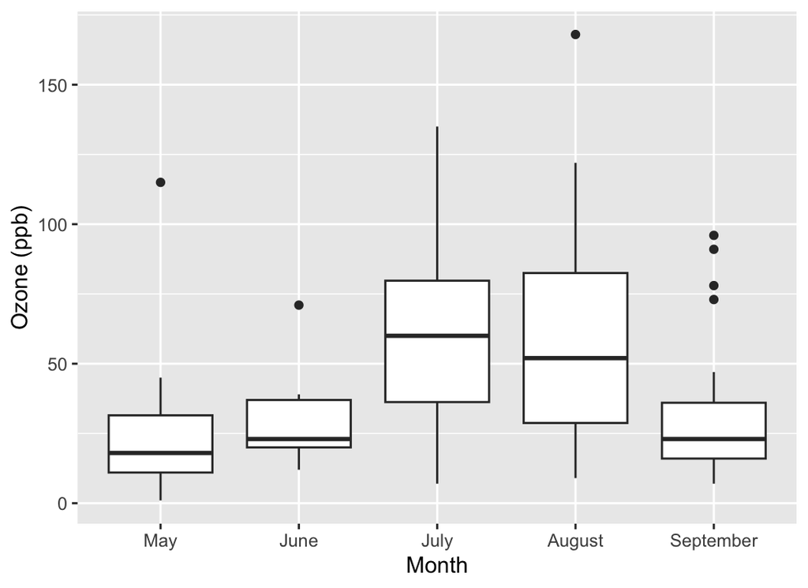

```r
airquality_month_named <-
  airquality_formatted %>%
  mutate(Month = factor(Month, levels = 5:9, labels = month.name[5:9]))

ggplot(airquality_month_named, aes(Month, Ozone)) +
  geom_boxplot(na.rm = TRUE) +
  labs(x = "Month", y = "Ozone (ppb)")
```

**Python**

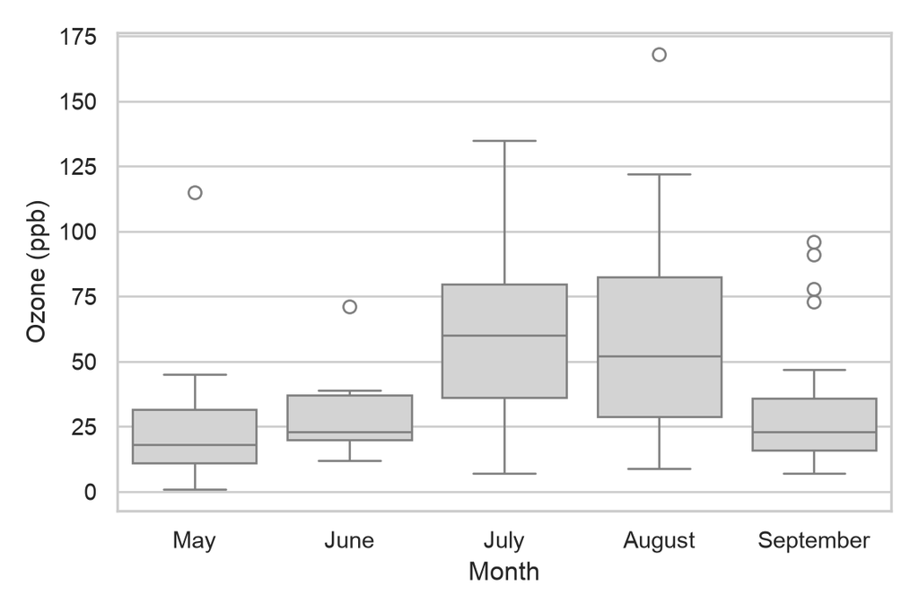

```python
month_order = ["May", "June", "July", "August", "September"]
airquality_month_named = airquality_formatted.copy()
airquality_month_named["Month"] = pd.Categorical(
    airquality_month_named["Date"].dt.month_name(locale="C"),
    categories=month_order, ordered=True
)

fig, ax = plt.subplots(figsize=(6, 4))
sns.boxplot(
    data=airquality_month_named, x="Month", y="Ozone", color="lightgray", ax=ax
)
ax.set(xlabel="Month", ylabel="Ozone (ppb)")
fig.tight_layout()
plt.show()
```

We can also count observed and missing ozone measurements in each month. The mean and median use only observed values and are in ppb.

**R**

```r
monthly_summary <-
  airquality_month_named %>%
  group_by(Month) %>%
  summarise(
    Observations = sum(!is.na(Ozone)),
    Missing = sum(is.na(Ozone)),
    Mean_Ozone = round(mean(Ozone, na.rm = TRUE), 1),
    Median_Ozone = median(Ozone, na.rm = TRUE),
    .groups = "drop"
  )

monthly_summary
```

```
# A tibble: 5 × 5
  Month     Observations Missing Mean_Ozone Median_Ozone
  <fct>            <int>   <int>      <dbl>        <dbl>
1 May                 26       5       23.6           18
2 June                 9      21       29.4           23
3 July                26       5       59.1           60
4 August              26       5       60             52
5 September           29       1       31.4           23
```

**Python**

```python
monthly_summary = (
    airquality_month_named.groupby("Month", observed=False, as_index=False)
    .agg(
        Observations=("Ozone", "count"),
        Missing=("Ozone", lambda values: values.isna().sum()),
        Mean_Ozone=("Ozone", "mean"),
        Median_Ozone=("Ozone", "median"),
    )
    .round({"Mean_Ozone": 1})
)
monthly_summary
```

```
       Month  Observations  Missing  Mean_Ozone  Median_Ozone
0        May            26        5        23.6          18.0
1       June             9       21        29.4          23.0
2       July            26        5        59.1          60.0
3     August            26        5        60.0          52.0
4  September            29        1        31.4          23.0
```

Which months have higher ozone levels, and how much do their distributions overlap? Notice that June has only nine observed values; its summary is based on much less data.

## Source code

This paired handout follows the R Air Quality worked example. The R dataset and Python CSV contain the same measurements, so comparisons use the same observed days in both languages.